# Supernova

```python
!jupyter nbconvert --to html "/content/drive/MyDrive/Study Material/SN_Fitting_Toy_Example.ipynb"
```

```
[NbConvertApp] Converting notebook /content/drive/MyDrive/Study Material/SN_Fitting_Toy_Example.ipynb to html
[NbConvertApp] Writing 1523516 bytes to /content/drive/MyDrive/Study Material/SN_Fitting_Toy_Example.html
```

#### Let's walk through a simplified "toy" example to illustrate how an astronomer might use the SED of a supernova to derive cosmological information.

**Scenario** : An astronomer observes a distant Type Ia supernova. The goal is to use this supernova to estimate the distance to its host galaxy, which can then provide information about the expansion rate of the Universe.

**Steps** :

1. **Observation** : The astronomer collects data across a range of wavelengths (from ultraviolet to near-infrared) over several weeks, mapping out the light curve of the supernova in each wavelength band.
2. **SED Construction** : For each observed time point, the astronomer constructs the SED by plotting the luminosity of the supernova against wavelength.
3. **SED Fitting with a Model** : Using a model (like SALT2), the astronomer fits the observed SEDs. This provides two crucial parameters:
   - ( x_1 ): Describes the shape of the light curve (how stretched or compressed it is compared to a standard).
   - ( c ): Describes the color (or more precisely, the brightness difference between two bands) of the supernova at its peak.
4. **Standardization** : Using the above parameters, the supernova's observed brightness is adjusted or "standardized." This means that even though not all Type Ia supernovae have the same intrinsic brightness, their light curves can be adjusted in a consistent way to act as "standard candles."
5. **Distance Estimation** : Using the standardized brightness and the observed brightness, the astronomer can estimate the distance modulus, and from that, the distance to the supernova (and its host galaxy).
6. **Cosmological Implication** : By observing many such supernovae at various distances (and hence, redshifts), the astronomer can plot the redshift against distance. The shape of this plot reveals the expansion history of the Universe. If the Universe's expansion is accelerating, this will be evident in the curve.

To visualize this, let's plot a simplified "SED" for our toy supernova and then show how it might look after fitting with a model.

Here's our toy plot:

- The blue curve represents the observed Spectral Energy Distribution (SED) of the supernova at its maximum light.
- The red dashed curve represents a model SED (e.g., something like a SALT2 model prediction).

By fitting the observed SED with the model (as shown), the astronomer can derive parameters like ( x_1 ) (shape/stretch of the light curve) and ( c ) (color at peak brightness). These parameters help in "standardizing" the supernova's brightness, turning it into a reliable distance indicator.

Once the supernova's intrinsic brightness is known, comparing it to the observed brightness gives the distance to the supernova and its host galaxy. By repeating this process for many supernovae at various redshifts, the astronomer can derive the expansion history of the Universe.

In the real world, the process is more complex, with sophisticated models and detailed SEDs. But this toy example gives a conceptual overview of how SEDs of supernovae are used in cosmological studies.

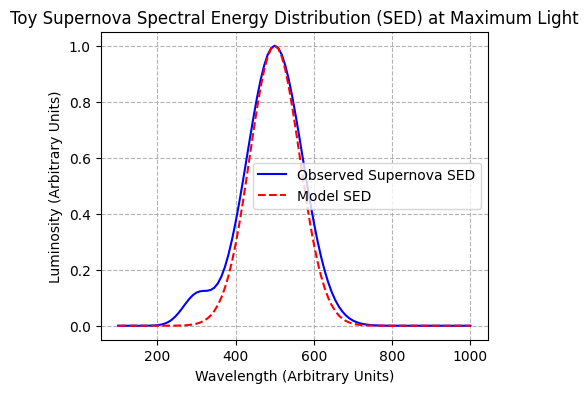

```python
# @title
import numpy as np
import matplotlib.pyplot as plt
# Toy SED for the supernova at maximum light
wavelengths = np.linspace(100, 1000, 100)  # Arbitrary units for wavelength
luminosity = np.exp(-((wavelengths - 500)/100)**2) + 0.1 * np.exp(-((wavelengths - 300)/50)**2)  # Toy SED

# Toy model SED (e.g., from SALT2)
model_luminosity = np.exp(-((wavelengths - 500)/90)**2)

# Plotting
plt.figure(figsize=(5, 4))
plt.plot(wavelengths, luminosity, label='Observed Supernova SED', color='blue')
plt.plot(wavelengths, model_luminosity, label='Model SED', linestyle='--', color='red')
plt.xlabel('Wavelength (Arbitrary Units)')
plt.ylabel('Luminosity (Arbitrary Units)')
plt.title('Toy Supernova Spectral Energy Distribution (SED) at Maximum Light')
plt.legend()
plt.grid(True, ls="--", c='0.7')
plt.show()
```

1. **Conclusion** : If the astronomer finds that distant supernovae are dimmer than expected (after standardization), it implies they are farther away than anticipated in a Universe with steady expansion. This was the groundbreaking discovery in the late 1990s that led to the concept of dark energy driving an accelerated cosmic expansion.

### Questions

The SEDs are fitted for each filter observatons ?

or all filter observations are condensed into one ?

and then fittted with the SED ?

alo are SEDs generally available for a specific wavelength limit ?

or it can be extended as much possible ?

all with respect to supernova ?

1. **Fitting SEDs for Each Filter vs. All Filters Together** :
   - Typically, observations in different filters provide the flux (or magnitude) of the supernova at various wavelengths at each time point. These fluxes from all filters at a given time can be combined to construct the SED for that specific epoch.
   - The SED model is then fit to these constructed SEDs over all observed epochs. So, instead of fitting the model to each filter's data separately, the data from all filters are combined to create a more complete SED, and the model is fit to this combined data. This approach provides a more holistic view of the supernova's spectral evolution.
2. **Wavelength Limits of SEDs** :
   - In principle, an SED covers the full range of the electromagnetic spectrum, from radio to gamma rays. However, in practice, the SED is limited by the observational capabilities.
   - For supernovae, the most informative parts of the SED are usually in the ultraviolet, optical, and near-infrared regions. These are the wavelengths where the supernova emits most of its energy, especially for Type Ia supernovae used in cosmology.
   - While there's no fundamental limit to how broad an SED can be, practical considerations (like the availability of telescopes sensitive to specific wavelength ranges) and the nature of the object being observed (a supernova might not emit significantly in, say, radio wavelengths until much later in its evolution) determine the effective range of the SED.
3. **Extending the SED** :
   - The SED can be extended as far as observations allow. For instance, late-time radio or X-ray observations might reveal interactions between the supernova ejecta and the surrounding medium. Early-time ultraviolet observations can provide insights into the explosion mechanism and the outer layers of the progenitor. However, extending the SED requires instruments that can observe in those specific wavelength ranges, and the supernova needs to have significant emission in those wavelengths for the observations to be meaningful.

In summary, while constructing and modeling the SED of a supernova, data from all available filters are typically combined to provide a comprehensive view of the supernova's emission across wavelengths. The effective range of the SED is determined by both the observational capabilities and the emission characteristics of the supernova itself.

### Observations and Light Curves:

First, let's consider the raw observations. When a supernova is observed, data is collected in multiple filters (e.g., UV, blue, green, red, infrared). For each filter, you get a light curve, which is a plot of brightness (or flux) versus time.

### Constructing the SED:

For each time point in these light curves, you can take the fluxes from each filter to construct an SED. The SED at a specific time shows the energy distribution of the supernova across different wavelengths at that moment.

### Fitting with a Model:

When you fit this observed SED with a model like SALT2, the model tries to reproduce the observed SED using a combination of model components. These components are based on a vast amount of prior supernova data. The SALT2 model, for instance, has a series of template spectra that it linearly combines to fit the observed SED.

### Extracting Parameters:

From this fitting process, you derive parameters that best describe how to adjust the model to fit the observed SED. Two of the most crucial parameters are:

1. **Stretch (( x_1 ))** : This parameter describes how "stretched" or "compressed" the light curve is compared to a standard Type Ia supernova light curve in the model. A positive ( x_1 ) value indicates a broader light curve, meaning the supernova took longer to rise and fall in brightness compared to the standard. A broader light curve also typically corresponds to a brighter supernova.
2. **Color (( c ))** : This parameter characterizes the color of the supernova at its peak brightness. In essence, it's describing the difference in brightness between two specific filters (often something like B-band and V-band). This parameter can account for intrinsic color differences in supernovae and for reddening due to dust in the host galaxy or along the line of sight.

### How Parameters Relate to the SED:

- The stretch parameter (( x_1 )) affects the time evolution of the SED. If the light curve is stretched, the SED's evolution will be slower. This means, for instance, that the time it takes for the SED to shift from being UV-dominant to red-dominant will be longer for a supernova with a larger ( x_1 ).
- The color parameter (( c )) influences the relative fluxes at different wavelengths in the SED. A "redder" supernova (with a higher ( c ) value) will have an SED that is suppressed in the blue/UV part and enhanced in the red part compared to a "bluer" supernova.

By fitting the model to the observed SED over multiple epochs (time points), the model provides the best-fit values of ( x_1 ) and ( c ) that describe the observed evolution and color of the supernova. Once these parameters are determined, they can be used to "standardize" the supernova's brightness, making it a more reliable distance indicator.

The SALT2 model for Type Ia supernovae uses a linear combination of template functions to fit the observed light curves. Once this fit is done, the derived parameters can be used to determine the distance modulus of the supernova. One of the most commonly used formulations for the distance modulus, which incorporates the stretch (( x_1 )) and color (( c )) parameters, is:

$ \mu = m_B - M + \alpha x_1 - \beta c $

Where:

- ( $\mu$ ) is the distance modulus, which is related to the distance of the supernova.
- ( $m_B$ ) is the observed peak brightness in the B-band (or a similar band).
- ( $M$ ) is the absolute B-band magnitude of a fiducial (or "standard") Type Ia supernova. This value needs to be calibrated using supernovae at known distances or other distance indicators.
- ( $\alpha$ ) is a parameter that describes how the luminosity of the supernova changes with the stretch factor ( x_1 ). It quantifies how much brighter or dimmer a supernova is for a given value of ( $x_1$ ) compared to the standard.
- ( x_1 ) is the stretch factor derived from the SALT2 fit, indicating how stretched or compressed the light curve is compared to a standard supernova light curve.
- ( $\beta$ ) is a parameter that quantifies how supernova luminosity changes with color. It accounts for the fact that redder supernovae (due to either intrinsic properties or dust) are generally dimmer.
- ( c ) is the color parameter from the SALT2 fit, typically representing the difference in brightness between two bands (often B and V) at peak brightness.

This equation serves as a way to "standardize" the observed peak brightness of the supernova. By incorporating the effects of stretch (( x_1 )) and color (( c )), the equation allows Type Ia supernovae, which are not all exactly the same intrinsic brightness, to serve as "standard candles" for measuring distances. The parameters ( \alpha ) and ( \beta ) are determined empirically from a set of well-observed supernovae, and they're crucial for this standardization process.

Let's visually represent how the stretch ( x_1 ) and color ( c ) parameters affect the observed peak brightness of a supernova and how they relate to the distance modulus ( \mu ).

We'll do the following:

1. Create a hypothetical set of supernovae with varying ( x_1 ) and ( c ) values.
2. Use the equation ( \mu = m_B - M + \alpha x_1 - \beta c ) to calculate the distance modulus for each supernova.
3. Plot these values to show the relationship between ( x_1 ), ( c ), and ( \mu ).

For simplicity, I'll use arbitrary values for ( M ), ( \alpha ), and ( \beta ). Let's proceed with this visualization.

It seems we encountered a technical issue with the plotting. Let me try to generate the plots again.

I apologize for the oversight. It appears that after the technical hiccup, I need to reinitialize the environment and variables. Let's set everything up again and then proceed with the plots.

Here are the visualizations:

Both of these plots provide a visual representation of how the stretch and color parameters, derived from the SED fitting, influence the apparent brightness (and thus the inferred distance) of a Type Ia supernova. By understanding and calibrating these relationships, astronomers can use Type Ia supernovae as "standard candles" to measure distances across the universe.

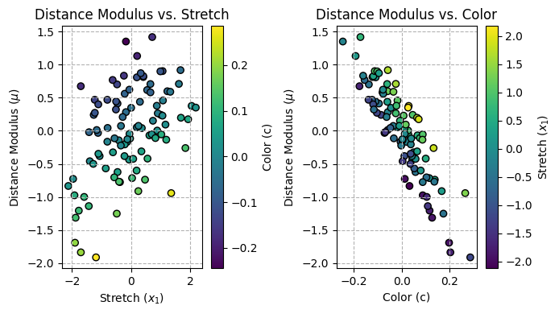

```python
import numpy as np
import matplotlib.pyplot as plt

# Arbitrary parameters for the demonstration
M = -19.3  # Absolute magnitude of a "standard" supernova
alpha = 0.15
beta = 3.0

# Generate hypothetical supernovae data
num_supernovae = 100
x1_values = np.random.normal(0, 1, num_supernovae)  # Random stretch values around 0
c_values = np.random.normal(0, 0.1, num_supernovae)  # Random color values around 0
mB_values = M + alpha * x1_values - beta * c_values + np.random.normal(0, 0.1, num_supernovae)  # Adding some noise

# Calculate the distance modulus for each supernova using the equation
mu_values = mB_values - M + alpha * x1_values - beta * c_values

# Plotting
plt.figure(figsize=(7, 4))

# Plot for x1 vs. mu
plt.subplot(1, 2, 1)
plt.scatter(x1_values, mu_values, c=c_values, cmap='viridis', edgecolor='k')
plt.colorbar(label='Color (c)')
plt.xlabel('Stretch ($x_1$)')
plt.ylabel('Distance Modulus ($\mu$)')
plt.title('Distance Modulus vs. Stretch')
plt.grid(True, ls="--", c='0.7')

# Plot for c vs. mu
plt.subplot(1, 2, 2)
plt.scatter(c_values, mu_values, c=x1_values, cmap='viridis', edgecolor='k')
plt.colorbar(label='Stretch ($x_1$)')
plt.xlabel('Color (c)')
plt.ylabel('Distance Modulus ($\mu$)')
plt.title('Distance Modulus vs. Color')
plt.grid(True, ls="--", c='0.7')

plt.tight_layout()
plt.show()
```

Let's break down the relationship between ( \alpha ), ( x_1 ), ( \beta ), and ( c ) and clarify which are fit and which are not.

### ( x_1 ) and ( c ):

- ( x_1 ) and ( c ) are derived directly from the observed light curves of the supernova using models like SALT2.
- ( x_1 ) represents the stretch or compression of the light curve relative to a "standard" Type Ia supernova. It tells us how much longer or shorter the observed light curve is compared to a typical one.
- ( c ) represents the color of the supernova around peak brightness, often capturing the difference in brightness between two specific filters.

Both ( x_1 ) and ( c ) are fit parameters. They are determined for each individual supernova based on its observed light curves and SED.

### ( \alpha ) and ( \beta ):

- ( \alpha ) and ( \beta ) are not fit for individual supernovae. Instead, they are determined empirically from a larger set of supernovae with well-understood distances (e.g., from host galaxies with known redshifts).
- ( \alpha ) quantifies how the intrinsic brightness of a supernova changes with its stretch parameter ( x_1 ).
- ( \beta ) quantifies how the intrinsic brightness of a supernova changes with its color ( c ).

Both ( \alpha ) and ( \beta ) are calibration constants. They are determined to "standardize" the brightness of Type Ia supernovae, so they can serve as "standard candles" for cosmology.

### Toy Example:

Let's create a simple toy example to demonstrate this:

1. We'll generate a set of hypothetical supernovae with random ( x_1 ) and ( c ) values.
2. We'll assign an arbitrary intrinsic brightness to each supernova based on a made-up ( \alpha ) and ( \beta ).
3. We'll then compare the "true" intrinsic brightnesses with those we'd infer using the ( \alpha ) and ( \beta ) values to see how well we can recover the true distances.

Let's proceed with this example.

In the plot above:

- The x-axis represents the "true" distance moduli of the supernovae, which were generated using the "true" values of ( \alpha ) and ( \beta ) that we set for this toy example.
- The y-axis represents the estimated distance moduli of the same supernovae, which were calculated using slightly different (and in this case, incorrect) values of ( \alpha ) and ( \beta ).
- The color of each point corresponds to its stretch value (( x_1 )).
- The red dashed line represents where points would lie if the estimated distance modulus was exactly equal to the true distance modulus.

From this plot, you can see that if ( \alpha ) and ( \beta ) are not accurately known, the estimated distances to the supernovae (as represented by the distance modulus) can deviate from their true values. This demonstrates the importance of accurately determining ( \alpha ) and ( \beta ) from a well-sampled set of supernovae to ensure that Type Ia supernovae can be reliably used as standard candles in cosmology.

In the real world, determining ( \alpha ) and ( \beta ) involves a more complex process that takes into account various uncertainties and uses a larger dataset of supernovae. But this toy example provides a conceptual illustration of their roles and importance.

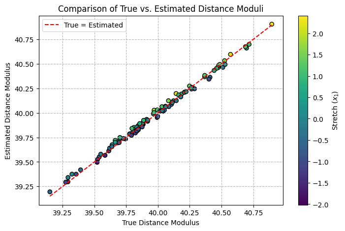

```python
# Generating toy supernovae data

# True alpha and beta values for this simulation
true_alpha = 0.14
true_beta = 2.8

# Generate random x1 and c values for our toy supernovae
x1_values = np.random.normal(0, 1, num_supernovae)
c_values = np.random.normal(0, 0.1, num_supernovae)

# Assign a true distance modulus to each supernova based on the true alpha and beta
# For simplicity, we'll use a constant base distance modulus for all supernovae.
base_distance_modulus = 40
true_mu_values = base_distance_modulus + true_alpha * x1_values - true_beta * c_values

# Now, let's pretend we don't know the true alpha and beta.
# We'll use slightly off values to estimate the distance modulus and see the difference.
estimated_alpha = 0.16
estimated_beta = 2.6
estimated_mu_values = base_distance_modulus + estimated_alpha * x1_values - estimated_beta * c_values

# Plotting
plt.figure(figsize=(8, 5))

# Plot the true vs estimated distance moduli
plt.scatter(true_mu_values, estimated_mu_values, c=x1_values, cmap='viridis', edgecolor='k')
plt.colorbar(label='Stretch ($x_1$)')
plt.plot([min(true_mu_values), max(true_mu_values)], [min(true_mu_values), max(true_mu_values)], 'r--', label="True = Estimated")
plt.xlabel('True Distance Modulus')
plt.ylabel('Estimated Distance Modulus')
plt.title('Comparison of True vs. Estimated Distance Moduli')
plt.legend()
plt.grid(True, ls="--", c='0.7')
plt.show()
```

Let's walk through the steps of a supernova survey, focusing on the use of Type Ia supernovae as distance indicators:

### 1. Observation and Data Collection:

- **Task** : Observe the sky repeatedly to find and monitor supernovae.
- **Outcome** : Obtain light curves in multiple filters (e.g., UV, blue, green, red) for each supernova candidate.

### 2. Supernova Identification and Classification:

- **Task** : From the observed candidates, identify which are actually supernovae and further classify them (e.g., Type Ia, Ib, II).
- **Outcome** : A catalog of identified Type Ia supernovae with their light curves.

### 3. Light Curve Fitting:

- **Task** : Fit light curves of each supernova with models like SALT2.
- **Outcome** : For each supernova, derive parameters like ( x_1 ) (stretch) and ( c ) (color).

  (Here we can visualize the observed light curve and the model fit to illustrate this step.)

### 4. Calibration using a Training Set:

- **Task** : Using a subset of supernovae with known distances (e.g., in the nearby universe or from host galaxies with known redshifts), determine the global parameters ( \alpha ) and ( \beta ).
- **Outcome** : Values of ( \alpha ) and ( \beta ) that standardize supernova brightness across the survey.

  (We can plot a scatter of ( x_1 ) vs. intrinsic brightness and ( c ) vs. intrinsic brightness for this calibration set.)

### 5. Distance Estimation:

- **Task** : For each supernova, use the derived ( x_1 ) and ( c ), along with the global ( \alpha ) and ( \beta ), to standardize its brightness and estimate its distance modulus.
- **Outcome** : Distance estimates to each supernova's host galaxy.

  (We can visualize the distribution of estimated distances.)

### 6. Cosmological Analysis:

- **Task** : With distance estimates in hand, plot them against redshifts to derive cosmological parameters, like the Hubble constant ( H_0 ) or parameters related to dark energy.
- **Outcome** : Insights into the expansion history of the universe.

  (A Hubble diagram, plotting distance modulus against redshift, can illustrate this step.)

Let's generate some illustrative plots for steps 3, 4, and 5 to visualize the process. We'll use a toy model for simplicity.

Here are the illustrative plots for steps 3, 4, and 5:

1. **Step 3: Light Curve Fitting** :
   - We have a simulated "observed" light curve (in blue) which has some noise added to the true light curve (in red).
   - By fitting models like SALT2 to such observed light curves, astronomers derive parameters like ( x_1 ) and ( c ) for each supernova.
2. **Step 4: Calibration using a Training Set** :
   - This plot shows a hypothetical set of supernovae for which we know the intrinsic brightness.
   - Each point represents a supernova, plotted by its stretch (( x_1 )) and intrinsic brightness. The color of each point indicates its color parameter (( c )).
   - From such a dataset, ( \alpha ) and ( \beta ) are derived, capturing the relationship between stretch, color, and intrinsic brightness.
3. **Step 5: Distance Estimation** :
   - Here we have a histogram showing the distribution of estimated distance moduli for our set of supernovae. This distribution is derived using the ( x_1 ) and ( c ) values of each supernova along with the calibrated ( \alpha ) and ( \beta ).
   - Each value in this distribution represents the estimated distance modulus (related to distance) of a supernova in our survey.

These visualizations offer a simplified view of the steps involved in a supernova survey. The actual processes are more sophisticated and require meticulous calibration, error analysis, and detailed modeling. But these illustrations provide a conceptual understanding of how raw observations are transformed into valuable cosmological information.

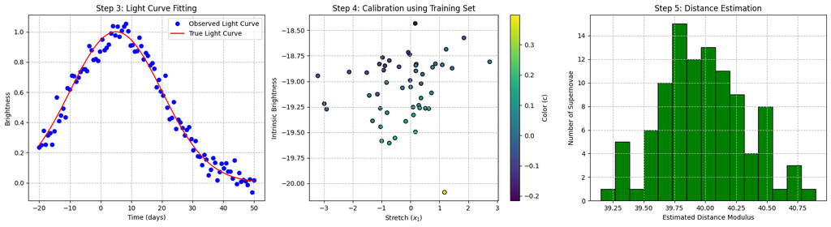

```python
# Simulating data for the steps

# Step 3: Light Curve Fitting
time = np.linspace(-20, 50, 100)  # Days relative to peak brightness
true_light_curve = np.exp(-0.5 * ((time - 5)/15)**2)  # Toy Gaussian light curve
observed_light_curve = true_light_curve + np.random.normal(0, 0.05, len(time))  # Adding some observational noise

# Step 4: Calibration using a Training Set
# Let's imagine we have a set of 50 supernovae with known distances
num_calibration = 50
calibration_x1_values = np.random.normal(0, 1, num_calibration)
calibration_c_values = np.random.normal(0, 0.1, num_calibration)
# Generate intrinsic brightnesses based on true alpha, beta and some scatter
calibration_brightnesses = -19 + true_alpha * calibration_x1_values - true_beta * calibration_c_values + np.random.normal(0, 0.1, num_calibration)

# Step 5: Distance Estimation
# For simplicity, let's just plot the distribution of estimated distances
# using the derived x1 and c values and the true alpha and beta
estimated_distances = base_distance_modulus + true_alpha * x1_values - true_beta * c_values

# Plotting
plt.figure(figsize=(18, 5))

# Step 3 Plot
plt.subplot(1, 3, 1)
plt.plot(time, observed_light_curve, 'o', label="Observed Light Curve", color='blue')
plt.plot(time, true_light_curve, label="True Light Curve", color='red')
plt.xlabel('Time (days)')
plt.ylabel('Brightness')
plt.title('Step 3: Light Curve Fitting')
plt.legend()
plt.grid(True, ls="--", c='0.7')

# Step 4 Plot
plt.subplot(1, 3, 2)
plt.scatter(calibration_x1_values, calibration_brightnesses, c=calibration_c_values, cmap='viridis', edgecolor='k')
plt.colorbar(label='Color (c)')
plt.xlabel('Stretch ($x_1$)')
plt.ylabel('Intrinsic Brightness')
plt.title('Step 4: Calibration using Training Set')
plt.grid(True, ls="--", c='0.7')

# Step 5 Plot
plt.subplot(1, 3, 3)
plt.hist(estimated_distances, bins=15, color='green', edgecolor='k')
plt.xlabel('Estimated Distance Modulus')
plt.ylabel('Number of Supernovae')
plt.title('Step 5: Distance Estimation')
plt.grid(True, ls="--", c='0.7')

plt.tight_layout()
plt.show()
```

### Scenario:

A supernova is observed in multiple filters, such as ultraviolet (U), blue (B), green (V), and red (R). Each filter will capture the brightness of the supernova at different wavelengths and will give us a light curve in that specific filter.

Once we have the light curves from all the filters, we can combine them to construct the Spectral Energy Distribution (SED) of the supernova at each time point.

### Steps:

1. Generate individual light curves for the supernova in the U, B, V, and R filters.
2. Visualize these light curves.
3. Combine the filter observations at a specific time to get the SED.
4. Visualize the SED.

Let's proceed with this simulation and visualization.

Here are the visualizations based on our toy model:

By combining observations from different filters, astronomers can construct the SED of a supernova and gain insights into its spectral properties, temperature, and composition. This combined information is crucial for understanding the underlying physics of the supernova and for standardizing its brightness for cosmological studies.

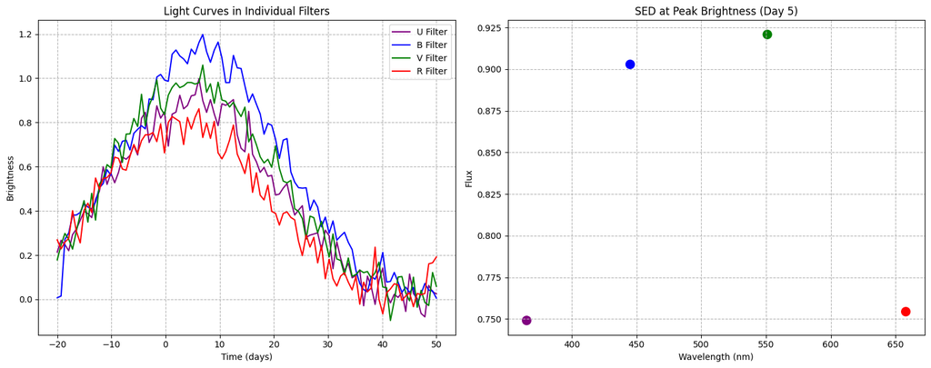

```python
# Simulating individual filter light curves

# Base light curve (similar to what we used before)
base_curve = np.exp(-0.5 * ((time - 5)/15)**2)

# Different filters will have different peak times and amplitudes
U_curve = 0.9 * base_curve + np.random.normal(0, 0.05, len(time))
B_curve = 1.1 * np.roll(base_curve, 2) + np.random.normal(0, 0.05, len(time))  # A 2-day shift for illustration
V_curve = base_curve + np.random.normal(0, 0.05, len(time))
R_curve = 0.8 * np.roll(base_curve, -3) + np.random.normal(0, 0.05, len(time))  # A 3-day shift for illustration

# SED at a specific time point (let's choose the peak of the base curve, i.e., day 5)
sed_wavelengths = [365, 445, 551, 658]  # Representative central wavelengths for U, B, V, and R in nm
sed_fluxes = [U_curve[25], B_curve[25], V_curve[25], R_curve[25]]  # Values at the peak of the base curve

# Plotting
plt.figure(figsize=(15, 6))

# Individual filter light curves
plt.subplot(1, 2, 1)
plt.plot(time, U_curve, label='U Filter', color='purple')
plt.plot(time, B_curve, label='B Filter', color='blue')
plt.plot(time, V_curve, label='V Filter', color='green')
plt.plot(time, R_curve, label='R Filter', color='red')
plt.xlabel('Time (days)')
plt.ylabel('Brightness')
plt.title('Light Curves in Individual Filters')
plt.legend()
plt.grid(True, ls="--", c='0.7')

# SED at the peak of the light curve
plt.subplot(1, 2, 2)
plt.scatter(sed_wavelengths, sed_fluxes, color=['purple', 'blue', 'green', 'red'], s=100)
plt.xlabel('Wavelength (nm)')
plt.ylabel('Flux')
plt.title('SED at Peak Brightness (Day 5)')
plt.grid(True, ls="--", c='0.7')

plt.tight_layout()
plt.show()
```

Luminosity (or brightness) as a function of time for a supernova is represented by its light curve. When you gather light curves from a sample of multiple Type Ia supernovae, you'll notice variability in both the shape (stretch) and the peak brightness (color and intrinsic variability).

The stretch and color correction process aims to standardize these light curves so that Type Ia supernovae can be treated as "standard candles."

Here's what you might expect:

1. **Before Correction** :
   - Light curves will have varying widths, with some supernovae having broader light curves (indicating they last longer) and others being narrower.
   - The peak brightness will also vary, with some supernovae appearing brighter and others dimmer. This variability is due to a combination of intrinsic differences, color differences, and differences in the actual distance to the supernovae.
2. **After Correction** :
   - The width of the light curves will be more standardized, meaning they will look more similar in shape.
   - The peak brightness will also be adjusted to account for the stretch and color, making the supernovae more consistent in their maximum luminosity.

Let's simulate and visualize this. We'll create a set of light curves for a sample of Type Ia supernovae, both before and after applying stretch and color corrections.

Here are the simulated light curves for a sample of Type Ia supernovae:

1. **Before Correction** (Left Panel):
   - The light curves display variability in both width and peak brightness. Some light curves are broader, indicating a longer-lasting supernova, while others are narrower. The peak brightness also varies among the supernovae.
2. **After Correction** (Right Panel):
   - After applying stretch and color corrections, the light curves are more standardized in terms of their shape and peak brightness. They are now more aligned, especially around the peak, which demonstrates the effect of the standardization process.

This visualization offers a simplistic representation of how stretch and color corrections can help in making Type Ia supernovae more consistent in their light curve properties, enabling their use as "standard candles" in cosmology. In real-world applications, the corrections are more nuanced and are based on detailed models and empirical calibrations.

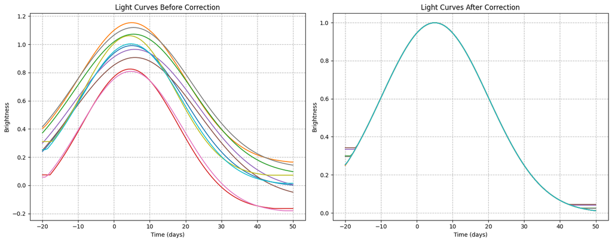

```python
# Simulating multiple Type Ia supernova light curves

num_sn = 10  # Number of supernovae to simulate

# Generate random stretch and color values for our sample
stretch_factors = np.random.uniform(0.8, 1.2, num_sn)
color_offsets = np.random.uniform(-0.2, 0.2, num_sn)

# Generate individual light curves based on the base_curve
light_curves = []
for i in range(num_sn):
    stretched_time = time * stretch_factors[i]
    stretched_curve = np.interp(time, stretched_time, base_curve)
    color_corrected_curve = stretched_curve + color_offsets[i]
    light_curves.append(color_corrected_curve)

# After correction
corrected_light_curves = []
for curve, stretch, color in zip(light_curves, stretch_factors, color_offsets):
    # Stretch correction (reverse the stretch)
    unstretched_time = time / stretch
    unstretched_curve = np.interp(time, unstretched_time, curve)
    # Color correction (reverse the color offset)
    corrected_curve = unstretched_curve - color
    corrected_light_curves.append(corrected_curve)

# Plotting
plt.figure(figsize=(15, 6))

# Before Correction
plt.subplot(1, 2, 1)
for curve in light_curves:
    plt.plot(time, curve)
plt.xlabel('Time (days)')
plt.ylabel('Brightness')
plt.title('Light Curves Before Correction')
plt.grid(True, ls="--", c='0.7')

# After Correction
plt.subplot(1, 2, 2)
for curve in corrected_light_curves:
    plt.plot(time, curve)
plt.xlabel('Time (days)')
plt.ylabel('Brightness')
plt.title('Light Curves After Correction')
plt.grid(True, ls="--", c='0.7')

plt.tight_layout()
plt.show()
```

More about : the process of calibrating Type Ia supernovae to serve as "standard candles" in cosmological studies. The idea is that, while Type Ia supernovae are generally consistent in their intrinsic brightness, there are still variations among them. These variations, particularly in terms of how the light curve stretches and the supernova's color, are captured by the parameters ( x_1 ) and ( c ). However, to truly use these supernovae as standard candles, we need to understand how these variations relate to intrinsic brightness. This is where ( \alpha ) and ( \beta ) come in.

Here's the rationale behind the statement:

1. **Training Set with Known Distances** :
   - We need a set of Type Ia supernovae for which we have independent, reliable distance measurements. This is typically achieved by focusing on supernovae in the nearby universe, where distances can be determined through methods other than the supernova brightness itself. Another common approach is to use supernovae in host galaxies with known redshifts, where the redshift-distance relationship is well-understood.
2. **Determining ( $\alpha$ ) and ( $\beta$ )** :
   - With this "training set" of supernovae, we can see how the brightness variations (as captured by ( x_1 ) and ( c )) relate to the known distances. The parameters ( \alpha ) and ( \beta ) are then determined to capture these relationships.
   - Essentially, ( \alpha ) quantifies how the intrinsic brightness of a supernova changes with its stretch parameter ( x_1 ), and ( \beta ) does the same for the color parameter ( c ).
3. **Why it's Important** :
   - By calibrating using supernovae with known distances, we ensure that when we apply these corrections (using ( \alpha ) and ( \beta )) to more distant supernovae (whose distances we don't know a priori), we get reliable distance estimates. This calibration is crucial for using Type Ia supernovae to study the expansion history of the universe.

In essence, this calibration step is about "training" our standard candle on a known dataset, so it can then be reliably used on unknown datasets. This approach is a cornerstone of many measurement techniques in science.